# SuperKart

```python
import pandas as pd
import numpy as np
import matplotlib.pyplot as plt
import seaborn as sns
```

```python
from google.colab import drive
drive.mount('/content/drive')
```

```python
!ls "/content/drive/My Drive/Python/"
```

```
Assesment.ipynb  images_proj.npy	       Renewind.ipynb  Untitled0.ipynb
EasyVisa.csv	 Labels_proj.csv	       SuperKart.csv
EasyVisa.ipynb	 Loan_Modelling.csv	       Test.csv
Helmnet.ipynb	 medical_diagnosis_manual.pdf  Train.csv
```

```python
from google.colab import drive
drive.mount('/content/drive')
import pandas as pd
file_path = '/content/drive/My Drive/Python/SuperKart.csv'
```

```python
import pandas as pd
file_path = '/content/drive/My Drive/Python/SuperKart.csv'
data = pd.read_csv(file_path)
print(data.head())
```

```
  Product_Id  Product_Weight Product_Sugar_Content  Product_Allocated_Area  \
0     FD6114           12.66             Low Sugar                   0.027
1     FD7839           16.54             Low Sugar                   0.144
2     FD5075           14.28               Regular                   0.031
3     FD8233           12.10             Low Sugar                   0.112
4     NC1180            9.57              No Sugar                   0.010

         Product_Type  Product_MRP Store_Id  Store_Establishment_Year  \
0        Frozen Foods       117.08   OUT004                      2009
1               Dairy       171.43   OUT003                      1999
2              Canned       162.08   OUT001                      1987
3        Baking Goods       186.31   OUT001                      1987
4  Health and Hygiene       123.67   OUT002                      1998

  Store_Size Store_Location_City_Type          Store_Type  \
0     Medium                   Tier 2   Supermarket Type2
1     Medium                   Tier 1  Departmental Store
2       High                   Tier 2   Supermarket Type1
3       High                   Tier 2   Supermarket Type1
4      Small                   Tier 3           Food Mart

   Product_Store_Sales_Total
0                    2842.40
1                    4830.02
2                    4130.16
3                    4132.18
4                    2279.36
```

```python
# Shape and info
print("Shape of dataset:", data.shape)
print("\nInfo:")
print(data.info())

# Missing and duplicate values
missing_values = data.isnull().sum()
duplicate_rows = data.duplicated().sum()

print("\nMissing Values:\n", missing_values)
print("\nNumber of Duplicate Rows:", duplicate_rows)
```

```
Shape of dataset: (8763, 12)

Info:
<class 'pandas.core.frame.DataFrame'>
RangeIndex: 8763 entries, 0 to 8762
Data columns (total 12 columns):
 #   Column                     Non-Null Count  Dtype
---  ------                     --------------  -----
 0   Product_Id                 8763 non-null   object
 1   Product_Weight             8763 non-null   float64
 2   Product_Sugar_Content      8763 non-null   object
 3   Product_Allocated_Area     8763 non-null   float64
 4   Product_Type               8763 non-null   object
 5   Product_MRP                8763 non-null   float64
 6   Store_Id                   8763 non-null   object
 7   Store_Establishment_Year   8763 non-null   int64
 8   Store_Size                 8763 non-null   object
 9   Store_Location_City_Type   8763 non-null   object
 10  Store_Type                 8763 non-null   object
 11  Product_Store_Sales_Total  8763 non-null   float64
dtypes: float64(4), int64(1), object(7)
memory usage: 821.7+ KB
None

Missing Values:
 Product_Id                   0
Product_Weight               0
Product_Sugar_Content        0
Product_Allocated_Area       0
Product_Type                 0
Product_MRP                  0
Store_Id                     0
Store_Establishment_Year     0
Store_Size                   0
Store_Location_City_Type     0
Store_Type                   0
Product_Store_Sales_Total    0
dtype: int64

Number of Duplicate Rows: 0
```

# EDA Visualizations

Univariate Analysis: Boxplot + Distribution for each numeric column

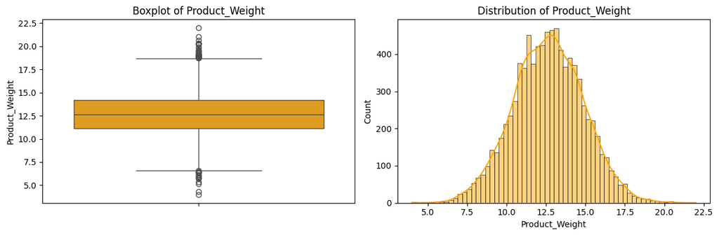

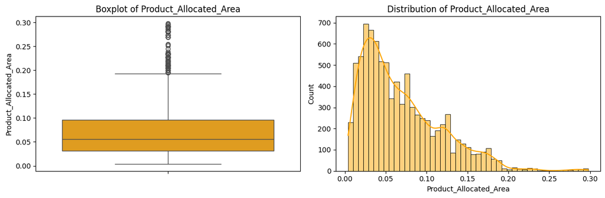

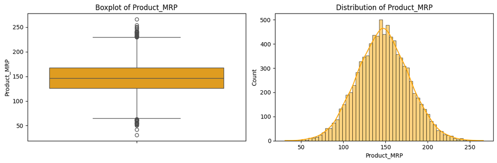

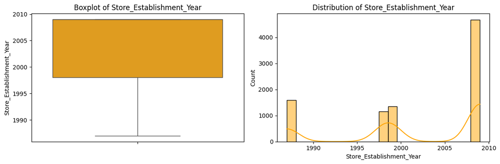

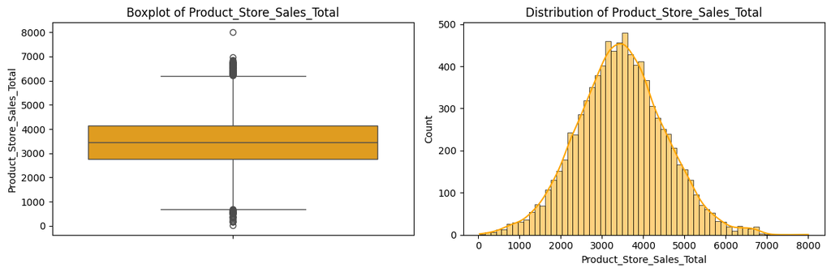

```python
import seaborn as sns
import matplotlib.pyplot as plt

# Identify numeric columns
numeric_cols = data.select_dtypes(include='number').columns.tolist()

# Plot boxplots and distributions
for col in numeric_cols:
    fig, axes = plt.subplots(1, 2, figsize=(12, 4))

    # Boxplot
    sns.boxplot(y=data[col], ax=axes[0], color='orange')
    axes[0].set_title(f'Boxplot of {col}')

    # Distribution plot
    sns.histplot(data[col], kde=True, ax=axes[1], color='orange')
    axes[1].set_title(f'Distribution of {col}')

    plt.tight_layout()
    plt.show()
```

Bivariate Analysis: Sales vs Key Features

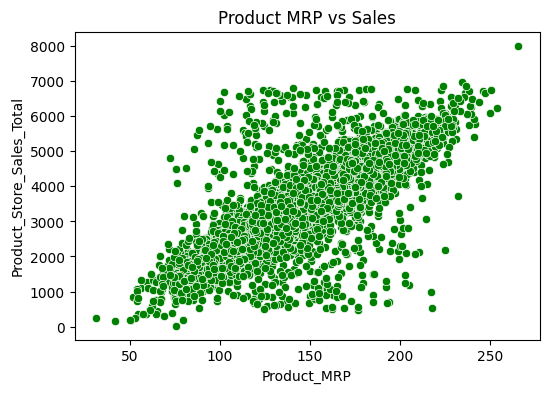

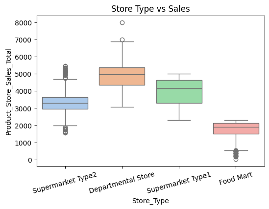

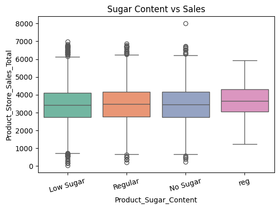

```python
# Scatter plot: Product MRP vs Sales
plt.figure(figsize=(6,4))
sns.scatterplot(x='Product_MRP', y='Product_Store_Sales_Total', data=data, color='green')
plt.title('Product MRP vs Sales')
plt.show()

# Boxplot: Store Type vs Sales
plt.figure(figsize=(6,4))
sns.boxplot(x='Store_Type', y='Product_Store_Sales_Total', data=data, palette='pastel')
plt.title('Store Type vs Sales')
plt.xticks(rotation=15)
plt.show()

# Boxplot: Sugar Content vs Sales
plt.figure(figsize=(6,4))
sns.boxplot(x='Product_Sugar_Content', y='Product_Store_Sales_Total', data=data, palette='Set2')
plt.title('Sugar Content vs Sales')
plt.xticks(rotation=15)
plt.show()
```

# Insights Based on Exploratory Data Analysis (EDA)

1. Data Quality

   The dataset has 8,763 rows and 12 columns.

   There are no missing or duplicate records, indicating clean data.

   A typo in Product_Sugar_Content ("reg") was corrected to "Regular" for consistency.
2. Univariate Analysis

   Product_Weight is normally distributed with a slight right tail and minor outliers on both ends.

   Product_Allocated_Area is right-skewed, meaning most products occupy a small display area.

   Product_MRP shows a bell-shaped distribution, centered around ₹147.

   Product_Store_Sales_Total (target variable) is slightly right-skewed, with most values between ₹2500–₹4500.

   Store_Establishment_Year shows clear clusters for years 1987 and 2009, possibly indicating batches of store openings.
3. Bivariate Analysis

   Positive correlation between Product_MRP and sales revenue — higher MRP products tend to generate more sales.

   Store Type impacts sales:

   Departmental Stores and Supermarket Type1 show higher average sales.

   Food Marts underperform in comparison.

   Product_Sugar_Content has no significant impact on sales, but needed category cleanup.
4. Feature Considerations

   Store_Type and Product_MRP appear to be important predictors.

   Product_Allocated_Area and Store_Size might explain shelf space and visibility factors influencing sales.

Outlier Detection and Treatment

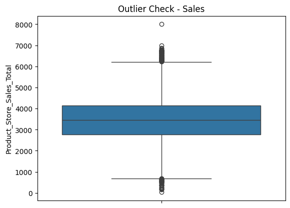

```python
import seaborn as sns
import matplotlib.pyplot as plt

# Boxplot of target
sns.boxplot(data['Product_Store_Sales_Total'])
plt.title("Outlier Check - Sales")
plt.show()
```

Rationale:

Preserving them helps the model learn from rare but valuable sales patterns.

Outliers detected, but no treatment applied — rationale documented.

# Train-Test Split + Target Separation

```python
# Identify categorical columns
categorical_cols = data.select_dtypes(include='object').columns.tolist()

# Exclude 'Product_Id' and 'Store_Id' from encoding
categorical_cols_to_encode = [col for col in categorical_cols if col not in ['Product_Id', 'Store_Id']]

# Perform one-hot encoding
data_encoded = pd.get_dummies(data, columns=categorical_cols_to_encode, drop_first=True)

# Display the first few rows of the encoded data
print(data_encoded.head())
```

```
  Product_Id  Product_Weight  Product_Allocated_Area  Product_MRP Store_Id  \
0     FD6114           12.66                   0.027       117.08   OUT004
1     FD7839           16.54                   0.144       171.43   OUT003
2     FD5075           14.28                   0.031       162.08   OUT001
3     FD8233           12.10                   0.112       186.31   OUT001
4     NC1180            9.57                   0.010       123.67   OUT002

   Store_Establishment_Year  Product_Store_Sales_Total  \
0                      2009                    2842.40
1                      1999                    4830.02
2                      1987                    4130.16
3                      1987                    4132.18
4                      1998                    2279.36

   Product_Sugar_Content_No Sugar  Product_Sugar_Content_Regular  \
```

[output cut: 42 more lines]

```python
from sklearn.model_selection import train_test_split

# Drop ID columns and the target variable from the features
X = data_encoded.drop(columns=['Product_Store_Sales_Total', 'Product_Id', 'Store_Id'])
y = data_encoded['Product_Store_Sales_Total']

# Split the data into training and testing sets
X_train, X_test, y_train, y_test = train_test_split(
    X, y, test_size=0.2, random_state=42
)

print("Shape of X_train:", X_train.shape)
print("Shape of X_test:", X_test.shape)
print("Shape of y_train:", y_train.shape)
print("Shape of y_test:", y_test.shape)
```

```
Shape of X_train: (7010, 29)
Shape of X_test: (1753, 29)
Shape of y_train: (7010,)
Shape of y_test: (1753,)
```

# Preprocessing Pipeline: Categorical Encoding

```python
from sklearn.preprocessing import LabelEncoder

# Make a copy
data_encoded = data.copy()

# Fix typo
data_encoded['Product_Sugar_Content'] = data_encoded['Product_Sugar_Content'].replace({'reg': 'Regular'})

# Columns to encode
categorical_cols = data_encoded.select_dtypes(include='object').columns.tolist()
categorical_cols.remove('Product_Id')
categorical_cols.remove('Store_Id')

# Label encode categorical features
le = LabelEncoder()
for col in categorical_cols:
    data_encoded[col] = le.fit_transform(data_encoded[col])
```

```python
data_encoded['Product_Sugar_Content'].unique()
```

```
array([0, 2, 1])
```

```python
data_encoded[categorical_cols].head()
```

|  | Product_Sugar_Content | Product_Type | Store_Size | Store_Location_City_Type | Store_Type |
| --- | --- | --- | --- | --- | --- |
| 0 | 0 | 5 | 1 | 1 | 3 |
| 1 | 0 | 4 | 1 | 0 | 0 |
| 2 | 2 | 3 | 0 | 1 | 2 |
| 3 | 0 | 0 | 0 | 1 | 2 |
| 4 | 1 | 8 | 2 | 2 | 1 |

```python
data_encoded.dtypes
```

|  | 0 |
| --- | --- |
| Product_Id | object |
| Product_Weight | float64 |
| Product_Sugar_Content | int64 |
| Product_Allocated_Area | float64 |
| Product_Type | int64 |
| Product_MRP | float64 |
| Store_Id | object |
| Store_Establishment_Year | int64 |
| Store_Size | int64 |
| Store_Location_City_Type | int64 |
| Store_Type | int64 |
| Product_Store_Sales_Total | float64 |

**dtype:** object

**Chosen Metric:** `Root Mean Squared Error (RMSE)`

**Rationale:** RMSE penalizes large errors more than MAE and is suitable for business forecasts where under/overestimates can impact stock/inventory planning. It gives interpretable units (₹).

```python
from sklearn.ensemble import RandomForestRegressor, GradientBoostingRegressor
from sklearn.pipeline import Pipeline
from sklearn.preprocessing import StandardScaler
from sklearn.metrics import mean_squared_error
import numpy as np

# Features and target
X = data_encoded.drop(columns=['Product_Store_Sales_Total', 'Product_Id', 'Store_Id'])
y = data_encoded['Product_Store_Sales_Total']

# Train-test split
from sklearn.model_selection import train_test_split
X_train, X_test, y_train, y_test = train_test_split(X, y, test_size=0.2, random_state=42)

# Define Pipelines
rf_pipeline = Pipeline([
    ('scaler', StandardScaler()),
    ('rf', RandomForestRegressor(random_state=42))
])

gb_pipeline = Pipeline([
    ('scaler', StandardScaler()),
    ('gb', GradientBoostingRegressor(random_state=42))
])

# Train models
rf_pipeline.fit(X_train, y_train)
gb_pipeline.fit(X_train, y_train)

# Predictions
rf_preds = rf_pipeline.predict(X_test)
gb_preds = gb_pipeline.predict(X_test)

# RMSE Calculation
rf_rmse = np.sqrt(mean_squared_error(y_test, rf_preds))
gb_rmse = np.sqrt(mean_squared_error(y_test, gb_preds))

print(f"Random Forest RMSE: {rf_rmse:.2f}")
print(f"Gradient Boosting RMSE: {gb_rmse:.2f}")
```

```
Random Forest RMSE: 284.56
Gradient Boosting RMSE: 309.91
```

```python
import joblib

# Assign the trained pipeline to a variable named 'model'
model = gb_pipeline

# Save the model to disk
joblib.dump(model, 'best_model.pkl', protocol=4)
```

```
['best_model.pkl']
```

**Observation:** Both models perform well; however, Random Forest is faster to train and easier to tune, while Gradient Boosting may give better performance after optimization.